# Question

A standard six-sided [die](https://en.wikipedia.org/wiki/Dice) was rolled 20 times, and the results were organized into the [histogram](https://en.wikipedia.org/wiki/Histogram) shown below. In [dice notation](https://en.wikipedia.org/wiki/Dice_notation), we could say the results of 20d6 were plotted as a histogram. (Pedantic sidenote: it is common to interpret 20d6 as the SUM of 20 rolls, but we will interpret 20d6 as the LIST of 20 rolls and use $\sum 20\text{d}6$ as the sum of 20 rolls.)

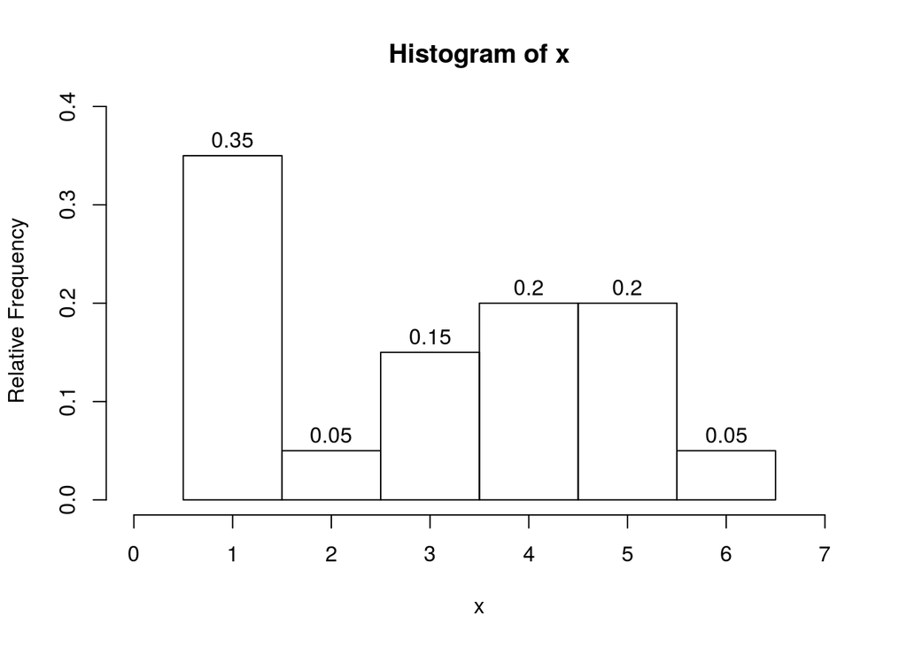

## Answerlist

- Evaluate $\text{prop}[\mathbf{x}<5.5]$.
- Evaluate $\text{prop}[\mathbf{x}>1.5]$.
- Evaluate $\text{prop}[|\mathbf{x}-3|<0.5]$.
- Evaluate $\text{prop}[|\mathbf{x}-3|>1.5]$.
- Evaluate half-integer boundary $b$ such that $\text{prop}[\mathbf{x}<b] = 0.75$.
- Evaluate half-integer boundary $b$ such that $\text{prop}[\mathbf{x}>b] = 0.25$.
- Evaluate integer radius $r$ such that $\text{prop}[|\mathbf{x}-2.5|<r] = 0.2$.
- Evaluate half-integer radius $r$ such that $\text{prop}[|\mathbf{x}-3|>r] = 0.6$.

# Solution

The first 4 questions involve adding up relative frequencies of the indicated intervals. The last 4 questions can be done by guessing and checking until something works.

You may also find it is helpful to determine frequencies (counts). You do this by multiplying each relative frequency by the total number of measurements.

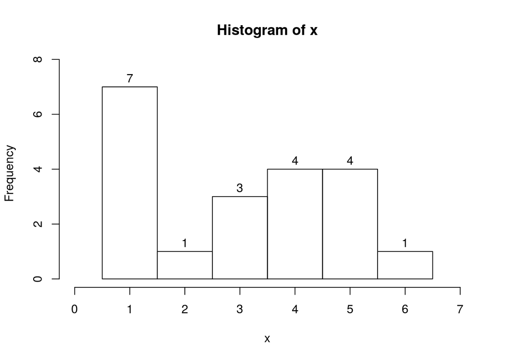

## Answerlist

- There are 19 measurements less than 5.5. So, $\text{prop}[\mathbf{x}<5.5]=\frac{19}{20}=0.95$.
- There are 13 measurements more than 1.5. So, $\text{prop}[\mathbf{x}>1.5]=\frac{13}{20}=0.65$.
- There are 3 measurements closer than 0.5 units from 3. So, $\text{prop}[|\mathbf{x}-3|<0.5]=\frac{3}{20}=0.15$.
- There are 12 measurements further than 1.5 units from 3. So, $\text{prop}[|\mathbf{x}-3|>1.5]=\frac{12}{20}=0.6$.
- First, convert the proportion into a count. $0.75\cdot20=15$. A boundary at $b=4.5$ has 15 measurements less than it. So, $\text{prop}[\mathbf{x}<4.5]=0.75$.
- First, convert the proportion into a count. $0.25\cdot20=5$. A boundary at $b=4.5$ has 5 measurements more than it. So, $\text{prop}[\mathbf{x}>4.5]=0.25$.
- An interval with radius $r=1$ around center 2.5 contains 4 measurements. So, $\text{prop}[|\mathbf{x}-2.5|<1]=0.2$.
- An interval with radius $r=1.5$ around center 3 excludes 12 measurements. So, $\text{prop}[|\mathbf{x}-3|>1.5]=0.6$.

# Meta-information

extype: cloze exclozetype: num|num|num|num|num|num|num|num exsolution: 0.95|0.65|0.15|0.6|4.5|4.5|1|1.5 exname: read_histogram_discrete_prop extol: 0.001 exextra[numwidth]: 999.99